# Inwiefern beeinflusst die Anomie die Fremdenfeindlichkeit?

```r
ff<-table2 %>%
  kbl(caption = "Quelle: ESS9-2018 ed. 3.0" ) %>%
  kable_material_dark()
ff
```

Quelle: ESS9-2018 ed. 3.0

|  | Variable | Kompenent_1 | Kompenent_2 | Kompenent_3 | komm |
| --- | --- | --- | --- | --- | --- |
| ppltrst | ppltrst | 0.6832312 | 0.1509268 | 0.0647650 | 0.5656865 |
| pplfair | pplfair | 0.8055796 | -0.0160179 | 0.0303744 | 0.6531709 |
| pplhlp | pplhlp | 0.7853472 | -0.0168281 | -0.0027923 | 0.6096287 |
| psppsgva | psppsgva | 0.0696496 | 0.8157410 | -0.0924843 | 0.6804623 |
| psppipla | psppipla | 0.0297300 | 0.8396371 | -0.0148220 | 0.7143750 |
| cptppola | cptppola | -0.2526868 | 0.4314738 | 0.3722195 | 0.3486859 |
| happy | happy | 0.2158365 | 0.1903647 | 0.3843918 | 0.3070982 |
| sclmeet | sclmeet | 0.0228528 | -0.1022901 | 0.7188598 | 0.5094950 |
| inprdsc | inprdsc | 0.1483281 | 0.0586459 | 0.5434371 | 0.3669904 |
| sclact | sclact | 0.0178505 | -0.0421037 | 0.7459283 | 0.5533048 |
| ifrjob | ifrjob | -0.0443124 | 0.4242071 | 0.2403629 | 0.2587818 |
| iprspot | iprspot | 0.2252223 | -0.2634898 | -0.1369478 | 0.1087639 |

**Alpha berechnen**

```r
psych::alpha(scale(anomia.z))
```

```
## Number of categories should be increased  in order to count frequencies.
```

```
## Some items ( iprspot ) were negatively correlated with the total scale and
## probably should be reversed.
## To do this, run the function again with the 'check.keys=TRUE' option
```

```
##
## Reliability analysis
## Call: psych::alpha(x = scale(anomia.z))
##
##   raw_alpha std.alpha G6(smc) average_r S/N    ase   mean   sd median_r
##       0.68      0.68     0.7      0.15 2.1 0.0097 -0.002 0.47     0.15
##
##  lower alpha upper     95% confidence boundaries
## 0.66 0.68 0.7
##
##  Reliability if an item is dropped:
##          raw_alpha std.alpha G6(smc) average_r S/N alpha se var.r med.r
## ppltrst       0.64      0.64    0.66      0.14 1.7   0.0110 0.016  0.15
## pplfair       0.64      0.64    0.66      0.14 1.8   0.0108 0.016  0.15
## pplhlp        0.65      0.65    0.67      0.14 1.9   0.0106 0.016  0.15
## psppsgva      0.65      0.65    0.66      0.14 1.8   0.0106 0.015  0.15
## psppipla      0.64      0.64    0.65      0.14 1.8   0.0108 0.015  0.15
## cptppola      0.67      0.67    0.70      0.16 2.0   0.0099 0.018  0.15
## happy         0.65      0.65    0.68      0.14 1.8   0.0107 0.019  0.14
## sclmeet       0.66      0.66    0.69      0.15 2.0   0.0102 0.019  0.16
## inprdsc       0.65      0.65    0.68      0.15 1.9   0.0105 0.019  0.15
## sclact        0.66      0.66    0.68      0.15 1.9   0.0104 0.018  0.15
## ifrjob        0.67      0.67    0.69      0.15 2.0   0.0101 0.019  0.15
## iprspot       0.72      0.72    0.73      0.19 2.5   0.0087 0.011  0.16
##
##  Item statistics
##             n raw.r std.r  r.cor r.drop     mean sd
## ppltrst  2358  0.59 0.587  0.552  0.451 -8.5e-18  1
## pplfair  2357  0.55 0.553  0.516  0.411  8.4e-18  1
## pplhlp   2355  0.52 0.517  0.464  0.369  6.3e-18  1
## psppsgva 2339  0.53 0.525  0.497  0.377  2.4e-17  1
## psppipla 2344  0.56 0.562  0.547  0.422 -9.4e-18  1
## cptppola 2340  0.40 0.395  0.281  0.230 -1.9e-18  1
## happy    2355  0.53 0.529  0.454  0.383 -7.9e-18  1
## sclmeet  2356  0.45 0.447  0.353  0.288 -4.0e-18  1
## inprdsc  2358  0.50 0.502  0.418  0.351 -2.8e-17  1
## sclact   2348  0.49 0.485  0.406  0.331  6.5e-18  1
## ifrjob   2280  0.43 0.428  0.323  0.267 -9.1e-18  1
## iprspot  2321  0.10 0.097 -0.092 -0.081  6.7e-18  1
```

**indexbildung**

```r
which(names(ess.DE)%in% c("psppipla","psppsgva","cptppola","ifrjob" ))
```

```
## [1]  14  16  17 488
```

```r
ess.DE$anomia<- rowMeans(ess.DE[,c(14, 16 , 17 , 488)])
table(is.na(ess.DE$anomia))
```

```
##
## FALSE  TRUE
##  2246   112
```

**die Beschreibung von der Index**

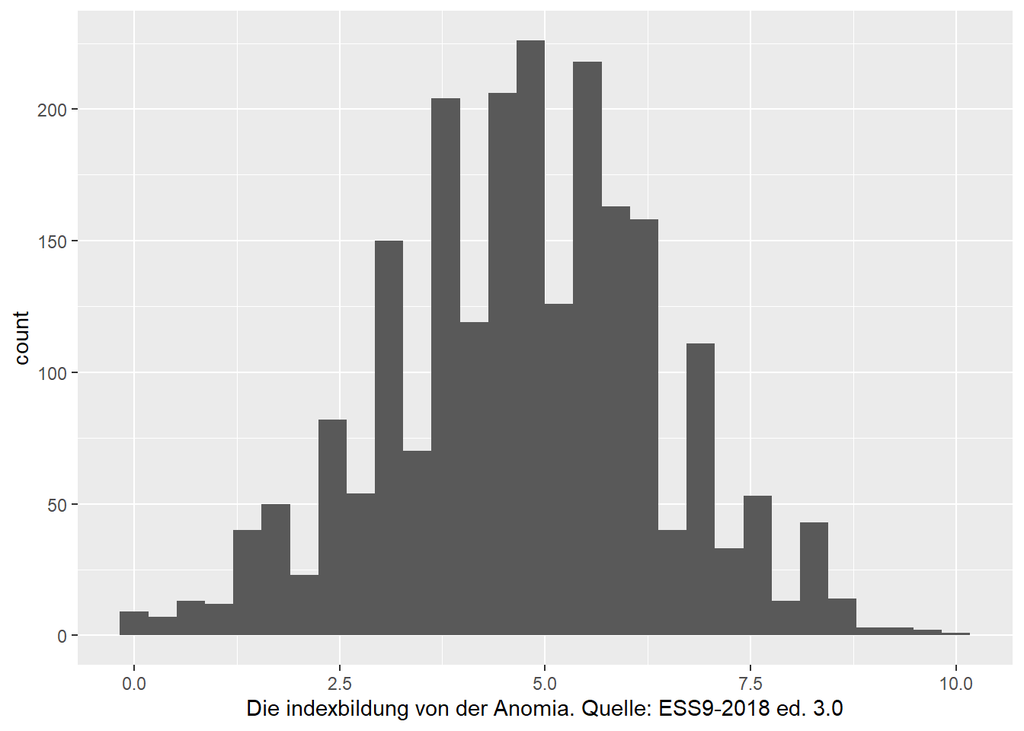

```r
ggplot(ess.DE, aes(anomia))+ geom_histogram()+
  xlab("Die indexbildung von der Anomia. Quelle: ESS9-2018 ed. 3.0")
```

```r
d2<-describe(ess.DE$anomia)

dd2<-d2 %>%
  kbl(caption = "Quelle: ESS9-2018 ed. 3.0") %>%
  kable_material_dark()
dd2
```

Quelle: ESS9-2018 ed. 3.0

|  | vars | n | mean | sd | median | trimmed | mad | min | max | range | skew | kurtosis | se |
| --- | --- | --- | --- | --- | --- | --- | --- | --- | --- | --- | --- | --- | --- |
| X1 | 1 | 2246 | 4.760407 | 1.67023 | 4.875 | 4.783579 | 1.667925 | 0 | 10 | 10 | -0.1229312 | -0.0453041 | 0.0352429 |

**Homophobi**

```r
homo<- c("freehms", "hmsfmlsh", "hmsacld")
describe(ess.DE[,homo])
```

```
##          vars    n mean   sd median trimmed  mad min max range  skew kurtosis
## freehms     1 2339 1.71 0.90      2    1.54 1.48   1   5     4  1.64     3.02
## hmsfmlsh    2 2341 4.25 1.03      5    4.45 0.00   1   5     4 -1.40     1.31
## hmsacld     3 2331 2.33 1.26      2    2.18 1.48   1   5     4  0.75    -0.54
##            se
## freehms  0.02
## hmsfmlsh 0.02
## hmsacld  0.03
```

**die Beschreibung von die ausgewälten Variablen**

```r
homo<- c("freehms", "hmsfmlsh", "hmsacld")
h<-describe(ess.DE[,homo])
homo.z<-scale(ess.DE[,homo])

hh<-h %>%
  kbl(caption = "Quelle: ESS9-2018 ed. 3.0") %>%
  kable_material_dark()
hh
```

Quelle: ESS9-2018 ed. 3.0

|  | vars | n | mean | sd | median | trimmed | mad | min | max | range | skew | kurtosis | se |
| --- | --- | --- | --- | --- | --- | --- | --- | --- | --- | --- | --- | --- | --- |
| freehms | 1 | 2339 | 1.714835 | 0.9026136 | 2 | 1.542445 | 1.4826 | 1 | 5 | 4 | 1.6446114 | 3.0191286 | 0.0186632 |
| hmsfmlsh | 2 | 2341 | 4.249466 | 1.0282987 | 5 | 4.447411 | 0.0000 | 1 | 5 | 4 | -1.4033503 | 1.3078211 | 0.0212529 |
| hmsacld | 3 | 2331 | 2.326898 | 1.2582609 | 2 | 2.182842 | 1.4826 | 1 | 5 | 4 | 0.7526241 | -0.5436209 | 0.0260615 |

[output not shown]

```
## Call:corr.test(x = homo.z, use = "complete")
## Correlation matrix
##          freehms hmsfmlsh hmsacld
## freehms     1.00    -0.58    0.56
## hmsfmlsh   -0.58     1.00   -0.45
## hmsacld     0.56    -0.45    1.00
## Sample Size
## [1] 2325
## Probability values (Entries above the diagonal are adjusted for multiple tests.)
##          freehms hmsfmlsh hmsacld
## freehms        0        0       0
## hmsfmlsh       0        0       0
## hmsacld        0        0       0
##
##  To see confidence intervals of the correlations, print with the short=FALSE option
```

```r
str(corr.test(homo.z,use = "complete")) #signfikant
```

[output not shown]

[figure not shown]

```r
cor.matrix.homo<- cor$r
ggcorrplot(cor.matrix.anomia, method = "circle" , title = "Quelle: ESS9-2018 ed. 3.0")
```

**2-lett TEST und KMO TEST**

```r
cortest.bartlett(homo.z)
```

```
## R was not square, finding R from data
```

```
## $chisq
## [1] 1940.229
##
## $p.value
## [1] 0
##
## $df
## [1] 3
```

```r
KMO(homo.z) #MSA > 6
```

```
## Kaiser-Meyer-Olkin factor adequacy
## Call: KMO(r = homo.z)
## Overall MSA =  0.68
## MSA for each item =
##  freehms hmsfmlsh  hmsacld
##     0.64     0.70     0.72
```

**die extrahierenden Faktoren**

```r
model.homo<- principal(homo.z, rotate = "oblimin")
model.homo$value
```

```
## [1] 2.0650126 0.5454704 0.3895170
```

```r
sum(model.homo$values)
```

```
## [1] 3
```

```r
sum(model.homo$values>1) #ES gibt 1 Dim
```

```
## [1] 1
```

**screeplot**

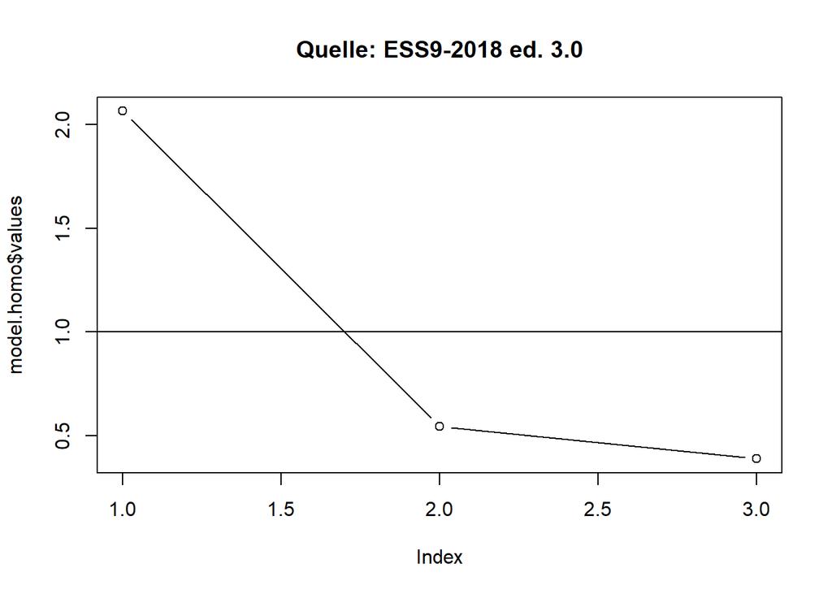

```r
plot(model.homo$values,type = "b")
abline(h=1)
title("Quelle: ESS9-2018 ed. 3.0")
```

**Es soll nur 1 Faktor extrahiert werden.**

```r
model.homo<-principal(homo.z, nfactors = 1, rotate = "oblimin")

tablehomo<- data.frame(Variable= row.names(as.matrix(model.homo$loadings[,1])),
                   Kompenent_1 = as.matrix(model.homo$loading[,1]), komm = as.matrix(model.homo$communality))
h1<-print.psych(model.anomia.2, cut= 0.3 , sort=T)
```

```
## Principal Components Analysis
## Call: principal(r = anomia.z, nfactors = 3, rotate = "oblimin")
## Standardized loadings (pattern matrix) based upon correlation matrix
##          item   TC2   TC1   TC3   h2   u2 com
## pplfair     2  0.81             0.65 0.35 1.0
## pplhlp      3  0.79             0.61 0.39 1.0
## ppltrst     1  0.68             0.57 0.43 1.1
## psppipla    5        0.84       0.71 0.29 1.0
## psppsgva    4        0.82       0.68 0.32 1.0
## cptppola    6        0.43  0.37 0.35 0.65 2.6
## ifrjob     11        0.42       0.26 0.74 1.6
## iprspot    12                   0.11 0.89 2.5
## sclact     10              0.75 0.55 0.45 1.0
## sclmeet     8              0.72 0.51 0.49 1.0
## inprdsc     9              0.54 0.37 0.63 1.2
## happy       7              0.38 0.31 0.69 2.1
##
##                        TC2  TC1  TC3
## SS loadings           1.95 1.92 1.80
## Proportion Var        0.16 0.16 0.15
## Cumulative Var        0.16 0.32 0.47
## Proportion Explained  0.34 0.34 0.32
## Cumulative Proportion 0.34 0.68 1.00
##
##  With component correlations of
##      TC2  TC1  TC3
## TC2 1.00 0.25 0.20
## TC1 0.25 1.00 0.16
## TC3 0.20 0.16 1.00
##
## Mean item complexity =  1.4
## Test of the hypothesis that 3 components are sufficient.
##
## The root mean square of the residuals (RMSR) is  0.09
##  with the empirical chi square  2444.94  with prob <  0
##
## Fit based upon off diagonal values = 0.8
```

```r
hh1<-tablehomo %>%
  kbl(caption = "Quelle: ESS9-2018 ed. 3.0" ) %>%
  kable_material_dark()
hh1
```

Quelle: ESS9-2018 ed. 3.0

|  | Variable | Kompenent_1 | komm |
| --- | --- | --- | --- |
| freehms | freehms | 0.8668800 | 0.7514809 |
| hmsfmlsh | hmsfmlsh | -0.8176316 | 0.6685215 |
| hmsacld | hmsacld | 0.8031253 | 0.6450103 |

**Alpha berechnen**

```r
psych::alpha(ess.DE[,homo])
```

```
## Some items ( hmsfmlsh ) were negatively correlated with the total scale and
## probably should be reversed.
## To do this, run the function again with the 'check.keys=TRUE' option
```

```
##
## Reliability analysis
## Call: psych::alpha(x = ess.DE[, homo])
##
##   raw_alpha std.alpha G6(smc) average_r   S/N   ase mean   sd median_r
##       -0.6      -0.7   0.089     -0.16 -0.41 0.052  2.8 0.53    -0.45
##
##  lower alpha upper     95% confidence boundaries
## -0.71 -0.6 -0.5
##
##  Reliability if an item is dropped:
##          raw_alpha std.alpha G6(smc) average_r   S/N alpha se var.r med.r
## freehms      -1.61     -1.67   -0.45     -0.45 -0.63    0.105    NA -0.45
## hmsfmlsh      0.69      0.71    0.56      0.56  2.50    0.012    NA  0.56
## hmsacld      -2.70     -2.75   -0.58     -0.58 -0.73    0.150    NA -0.58
##
##  Item statistics
##             n  raw.r  std.r r.cor r.drop mean  sd
## freehms  2339  0.637  0.683  0.98  0.085  1.7 0.9
## hmsfmlsh 2341 -0.044 -0.024 -1.58 -0.573  4.2 1.0
## hmsacld  2331  0.825  0.770  1.02  0.037  2.3 1.3
##
## Non missing response frequency for each item
##             1    2    3    4    5 miss
## freehms  0.49 0.40 0.06 0.03 0.02 0.01
## hmsfmlsh 0.03 0.06 0.11 0.26 0.55 0.01
## hmsacld  0.30 0.37 0.11 0.14 0.08 0.01
```

**Es soll nur ein Faktor extrahiert werden.**

**indexbildung Homophobie**

```r
ess.DE$homo<- rowMeans(ess.DE[,homo])
table(is.na(ess.DE$homo))
```

```
##
## FALSE  TRUE
##  2322    36
```

**die Beschreibung von der Index**

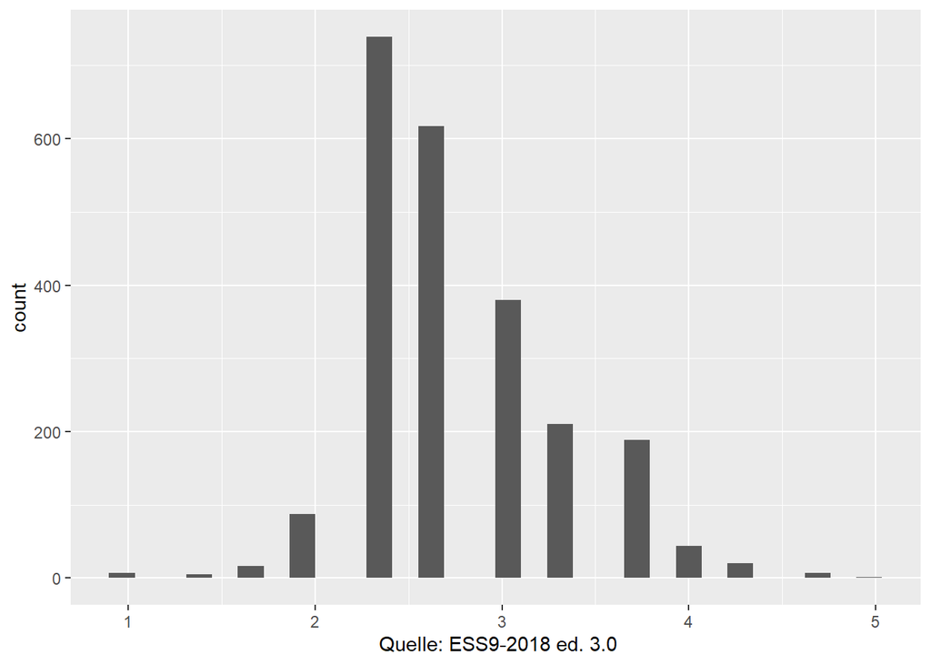

```r
ggplot(ess.DE, aes(ess.DE$homo))+ geom_histogram()+
  xlab(" Quelle: ESS9-2018 ed. 3.0")
```

```r
h2<-describe(ess.DE$homo)

hh2<-h2 %>%
  kbl(caption = "Quelle: ESS9-2018 ed. 3.0") %>%
  kable_material_dark()
hh2
```

Quelle: ESS9-2018 ed. 3.0

|  | vars | n | mean | sd | median | trimmed | mad | min | max | range | skew | kurtosis | se |
| --- | --- | --- | --- | --- | --- | --- | --- | --- | --- | --- | --- | --- | --- |
| X1 | 1 | 2322 | 2.763709 | 0.5230664 | 2.666667 | 2.714209 | 0.4942 | 1 | 5 | 4 | 0.6936063 | 0.7785144 | 0.0108549 |

**Wohnort Variable**

```r
describe(ess.DE$domicil)
```

```
##    vars    n mean   sd median trimmed  mad min max range  skew kurtosis   se
## X1    1 2358 2.88 1.08      3    2.95 1.48   1   5     4 -0.39    -0.79 0.02
```

```r
table(ess.DE$domicil)
```

```
##
##   1   2   3   4   5
## 364 377 843 715  59
```

```r
table(is.na(ess.DE$domicil))
```

```
##
## FALSE
##  2358
```

# Bivarite Statistics

**Fremdfeinlichkeit und Anomia**

```r
reg.model1<-lm( fremdhate~anomia , data =ess.DE)
summary(reg.model1)
```

```
##
## Call:
## lm(formula = fremdhate ~ anomia, data = ess.DE)
##
## Residuals:
##     Min      1Q  Median      3Q     Max
## -6.2760 -1.0973  0.0396  1.2636  5.7365
##
## Coefficients:
##             Estimate Std. Error t value Pr(>|t|)
## (Intercept)   4.2635     0.1162   36.68   <2e-16 ***
## anomia        0.4287     0.0230   18.63   <2e-16 ***
## ---
## Signif. codes:  0 '***' 0.001 '**' 0.01 '*' 0.05 '.' 0.1 ' ' 1
##
## Residual standard error: 1.776 on 2169 degrees of freedom
##   (187 observations deleted due to missingness)
## Multiple R-squared:  0.138,  Adjusted R-squared:  0.1376
## F-statistic: 347.2 on 1 and 2169 DF,  p-value: < 2.2e-16
```

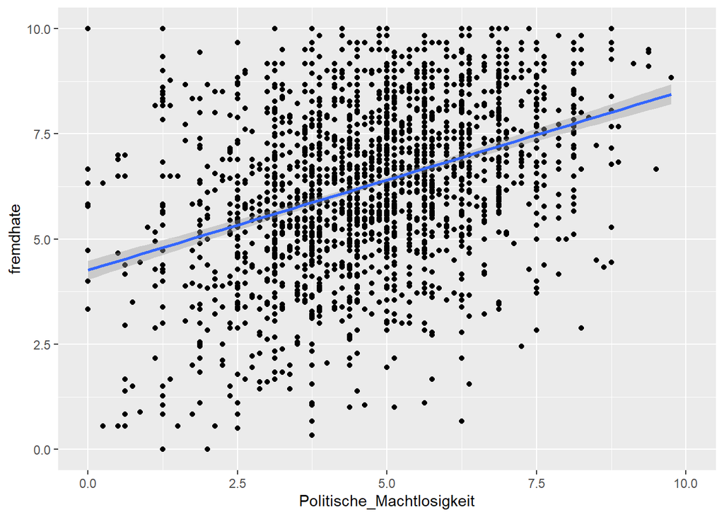

```r
ess.DE$Politische_Machtlosigkeit <- ess.DE$anomia


 ggplot(ess.DE,aes(x= Politische_Machtlosigkeit , y= fremdhate ))+
  geom_point()+
  geom_smooth(method = "lm")
```

**kontrolvariablen**

```r
reg.model2<-lm( fremdhate~anomia + homo + domicil , data =ess.DE)
summary(reg.model2)
```

```
##
## Call:
## lm(formula = fremdhate ~ anomia + homo + domicil, data = ess.DE)
##
## Residuals:
##     Min      1Q  Median      3Q     Max
## -6.3378 -1.0669  0.0369  1.1928  5.8321
##
## Coefficients:
##             Estimate Std. Error t value Pr(>|t|)
## (Intercept)  6.46957    0.25683  25.190  < 2e-16 ***
## anomia       0.41198    0.02273  18.126  < 2e-16 ***
## homo        -0.58531    0.07229  -8.096 9.39e-16 ***
## domicil     -0.17534    0.03499  -5.011 5.86e-07 ***
## ---
## Signif. codes:  0 '***' 0.001 '**' 0.01 '*' 0.05 '.' 0.1 ' ' 1
##
## Residual standard error: 1.74 on 2147 degrees of freedom
##   (207 observations deleted due to missingness)
## Multiple R-squared:  0.1734, Adjusted R-squared:  0.1723
## F-statistic: 150.1 on 3 and 2147 DF,  p-value: < 2.2e-16
```

```r
lm.beta(reg.model2)
```

```
##      anomia        homo     domicil
##  0.35670822 -0.15923872 -0.09843007
```

**Wohnort Variable b= -0.175 signifkant** 1 A big city 2 Suburbs or outskirts of big city 3 Town or small city 4 Country village 5 Farm or home in countryside